# Getting Started with soilgraph

## Overview

**soilgraph** provides tools for structuring soil profile descriptions, exporting them to JSON, and generating profile visualizations. A typical workflow is:

1. Prepare a structured table of horizon properties (or load a `.soil.json` file).
2. Build a `soil_profile` object.
3. Visualize the profile.
4. Export to the `.soil.json` format for archival and exchange.

```r
if (!requireNamespace("soilgraph", quietly = TRUE)) {
  if (!requireNamespace("devtools", quietly = TRUE)) {
    stop(
      "Package 'soilgraph' is not installed. Install it, or install 'devtools' ",
      "and render from the repository so the package can be loaded from source."
    )
  }

  pkg_root_candidates <- c(".", "..")
  pkg_root <- pkg_root_candidates[file.exists(file.path(pkg_root_candidates, "DESCRIPTION"))][1]

  if (is.na(pkg_root)) {
    stop("Could not find package root containing DESCRIPTION.")
  }

  devtools::load_all(path = pkg_root, quiet = TRUE)
}

library(soilgraph)
```

## Creating a structured horizon table

The recommended approach is to enter your horizon data as a data frame with explicit columns. At minimum you need `Top` and `Bottom` depths; all other fields are optional:

```r
horizons_df <- data.frame(
  Top = c(0, 18, 52),
  Bottom = c(18, 52, 95),
  Horizon = c("Ap", "Bt1", "Bt2"),
  Texture = c("silt loam", "clay loam", "clay"),
  Color = c("#5C4033", "#8A5A44", "#A66A4C"),
  Moisture = c("moist", "slightly moist", "dry"),
  BoundaryGrade = c("clear", "gradual", "diffuse"),
  BoundaryShape = c("smooth", "wavy", "irregular"),
  CoarseAbundance = c("few", "common", "many"),
  CoarseShape = c("subangular", "rounded", "subrounded"),
  CoarseGrade = c("weak", "moderate", "strong"),
  stringsAsFactors = FALSE
)
horizons_df
```

```
#>   Top Bottom Horizon   Texture   Color       Moisture BoundaryGrade
#> 1   0     18      Ap silt loam #5C4033          moist         clear
#> 2  18     52     Bt1 clay loam #8A5A44 slightly moist       gradual
#> 3  52     95     Bt2      clay #A66A4C            dry       diffuse
#>   BoundaryShape CoarseAbundance CoarseShape CoarseGrade
#> 1        smooth             few  subangular        weak
#> 2          wavy          common     rounded    moderate
#> 3     irregular            many  subrounded      strong
```

Both `PascalCase` (`BoundaryGrade`) and `snake_case` (`boundary_grade`) column names are recognized.

## Building a soil profile object

`soil_profile_from_table()` converts a horizon table into a `soil_profile` object, which is the primary data structure used by all plotting and export functions:

```r
profile <- soil_profile_from_table(
  horizons_df,
  site_id = "pedon-001",
  classification = list(
    system = "Soil Taxonomy",
    taxon  = "Typic Hapludalf"
  ),
  metadata = list(country = "Chile", land_use = "cropland")
)
```

You can also build profiles manually from individual horizons:

```r
h1 <- new_soil_horizon(0, 18,
  label = "Ap", color = "#5C4033",
  texture = "silt loam", boundary_grade = "clear", boundary_shape = "smooth"
)
h2 <- new_soil_horizon(18, 52,
  label = "Bt1", color = "#8A5A44",
  texture = "clay loam", boundary_grade = "gradual", boundary_shape = "wavy"
)
h3 <- new_soil_horizon(52, 95,
  label = "Bt2", color = "#A66A4C",
  texture = "clay", boundary_grade = "diffuse", boundary_shape = "irregular"
)

profile_manual <- new_soil_profile(
  site_id = "pedon-001",
  horizons = list(h1, h2, h3),
  classification = list(system = "Soil Taxonomy", taxon = "Typic Hapludalf")
)
```

Use `validate_soil_profile()` to check depth ordering and overlap constraints:

```r
validate_soil_profile(profile_manual)
```

## Plotting

### Basic profile

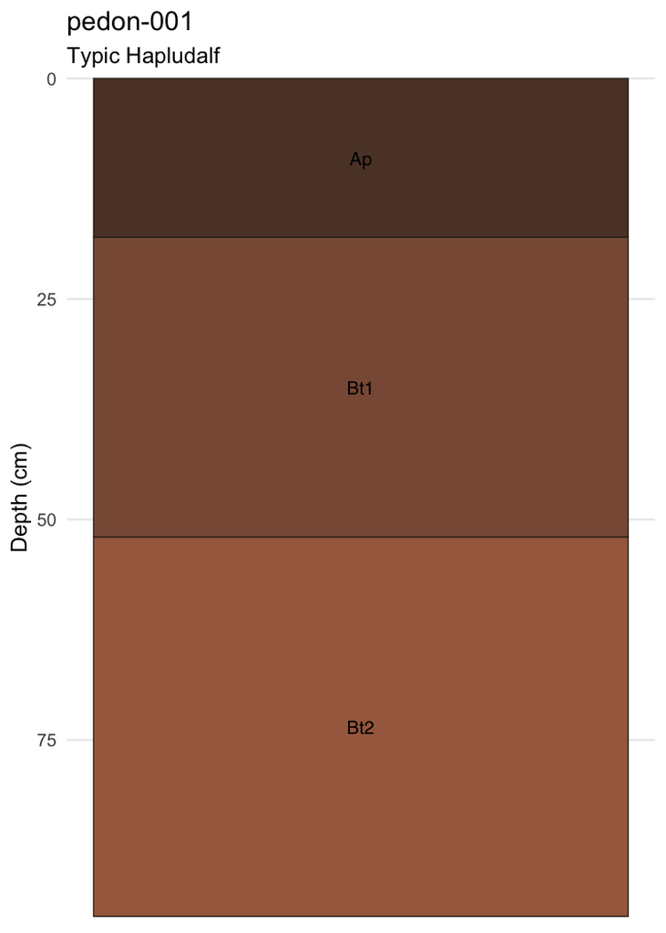

Basic soil profile visualization.

```r
plot_soil_profile(profile)
```

### Profile with coarse fragment markers

Point-based markers encode fragment type (shape), size (point size), and cementation grade (alpha):

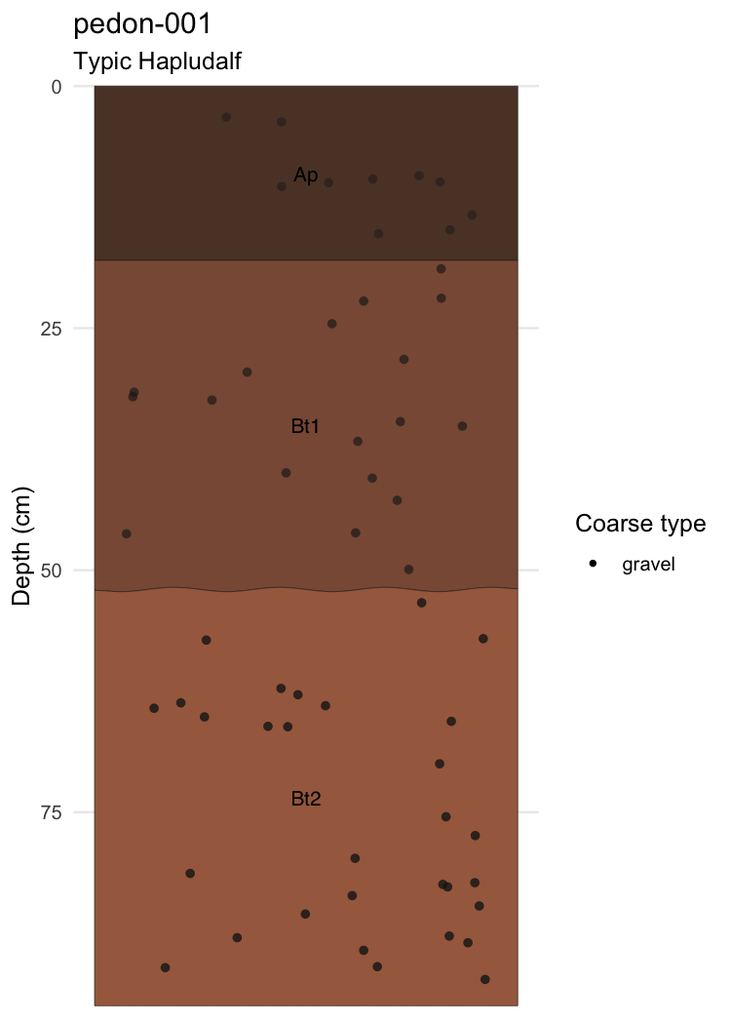

Profile with coarse fragment point markers.

```r
plot_soil_profile_fragments(profile, seed = 42)
```

### Advanced visualization

The advanced renderer uses polygon-based fragments and shaped horizon fills, where horizon edges follow encoded boundary topography/distinctness:

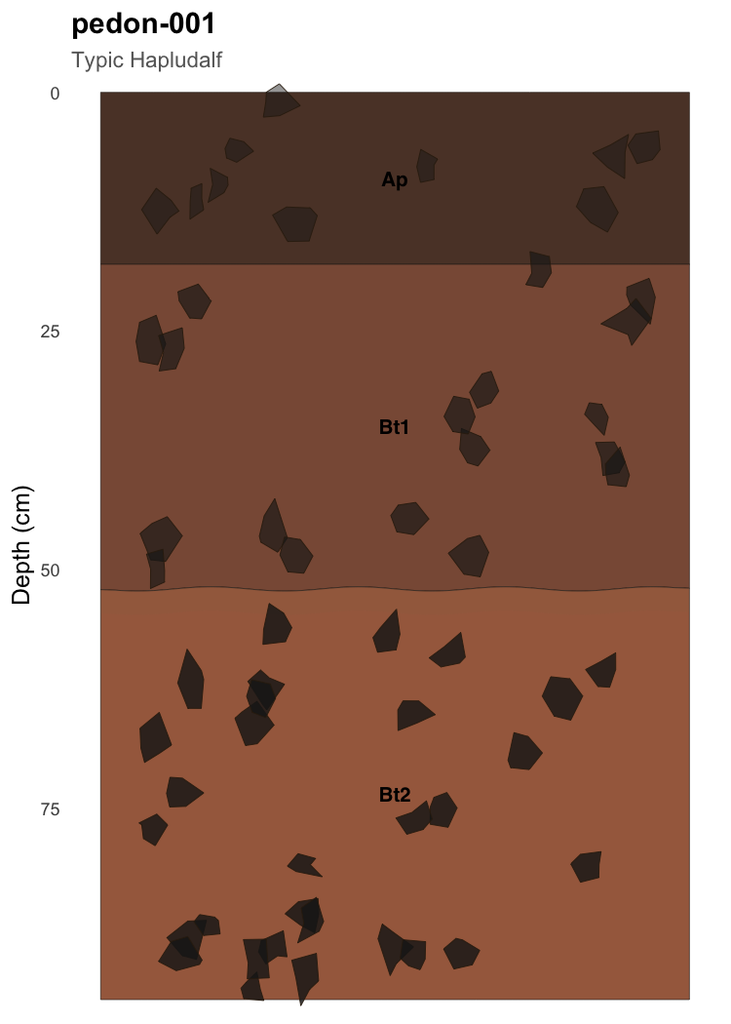

Advanced profile with polygon fragments, shaped horizon edges, and transition ribbons.

```r
plot_soil_profile_advanced(profile, seed = 42)
```

### Plotting directly from structured tables

For quick visualization you can go from table to plot in two steps:

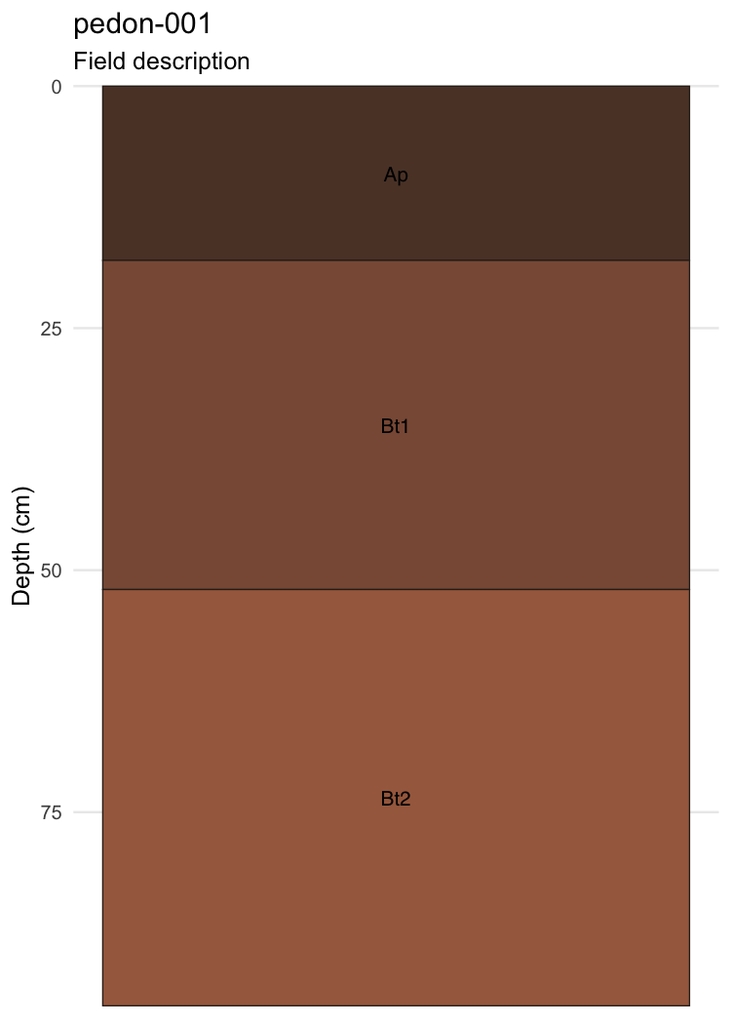

Plot from a structured table.

```r
quick_profile <- soil_profile_from_table(horizons_df, site_id = "pedon-001")
plot_soil_profile(quick_profile)
```

## Exporting and importing JSON

The `.soil.json` format stores profiles with all metadata in a standardized schema:

```r
# Write to a temporary file
tmp <- tempfile(fileext = ".soil.json")
write_soil_json(profile, tmp)

# Inspect the JSON structure
cat(readLines(tmp, n = 15), sep = "\n")
```

```
#> {
#>   "schema_version": "0.1.0",
#>   "site_id": "pedon-001",
#>   "classification": {
#>     "system": "Soil Taxonomy",
#>     "taxon": "Typic Hapludalf"
#>   },
#>   "metadata": {
#>     "country": "Chile",
#>     "land_use": "cropland"
#>   },
#>   "horizons": [
#>     {
#>       "top": 0,
#>       "bottom": 18,
```

Read it back:

```r
profile_reloaded <- read_soil_json(tmp)
profile_reloaded$site_id
```

```
#> [1] "pedon-001"
```

```r
profile_reloaded$classification$taxon
```

```
#> [1] "Typic Hapludalf"
```

```r
length(profile_reloaded$horizons)
```

```
#> [1] 3
```

## Reading bundled example data

The package ships with example files in `inst/extdata/`:

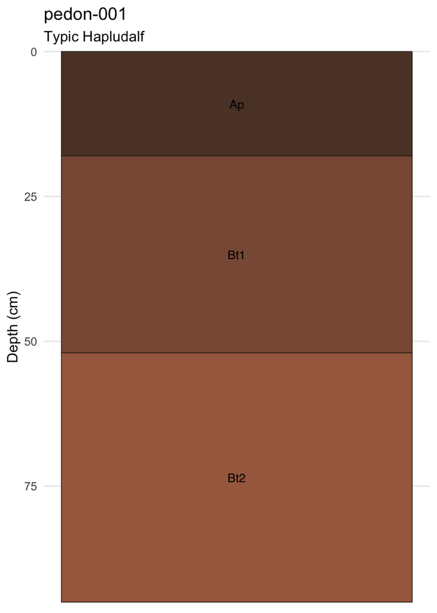

```r
json_path <- system.file("extdata", "example.soil.json", package = "soilgraph")
example_profile <- read_soil_json(json_path)
plot_soil_profile(example_profile)
```

## Next steps

- Learn about the advanced graphical engines in `vignette("graphical-engines")`.
- Explore the soil data model and supported vocabulary in `vignette("soil-data-model")`.
- Browse a gallery of rendering examples in `vignette("rendering-examples")`.

## Migrating from the free-text parser

Prior versions of soilgraph offered `derive_soil_horizons()` and `plot_soil_description()` to extract soil properties from free-text descriptions. These functions are now **deprecated**. The recommended migration is straightforward:

**Before (deprecated):**

```r
field_notes <- data.frame(
  Depth = c("0-18 cm", "18-52 cm"),
  description = c(
    "Ap dark brown silt loam moist clear smooth",
    "Bt1 reddish brown clay loam gradual wavy"
  )
)
profile <- soil_profile_from_table(field_notes, site_id = "pedon-001")
plot_soil_description(field_notes, site_id = "pedon-001")
```

**After (structured):**

```r
horizons_df <- data.frame(
  Top = c(0, 18),
  Bottom = c(18, 52),
  Horizon = c("Ap", "Bt1"),
  Texture = c("silt loam", "clay loam"),
  Color = c("#5C4033", "#8A5A44"),
  Moisture = c("moist", NA),
  BoundaryGrade = c("clear", "gradual"),
  BoundaryShape = c("smooth", "wavy"),
  stringsAsFactors = FALSE
)
profile <- soil_profile_from_table(horizons_df, site_id = "pedon-001")
plot_soil_profile(profile)
```

The structured approach is more explicit, more reliable, and lets you control exactly which properties are recorded for each horizon.